# Tutorial 6: Introduction to Numpy

Programming for Engineers (ENGG1001)

Published

January 30, 2026

## Tutorial Tasks

- Task 1: Understanding the Difference Between Lists and Numpy Arrays
- Task 2: Understanding Numpy Documentation
- Task 3: Understanding Vectorized Operations in Numpy
- Task 4: Ways to Create Numpy Arrays
- Task 5: Projectile Motion With Numpy

## Revision

In Module 1, you used the function range on a number of occasions, e.g. in loops. However, range only works with integers. In this tutorial, we will be introduced to Numpy, a powerful library for numerical computing in Python that provides support for arrays and matrices, along with a collection of mathematical functions to operate on these data structures. To start with, lets revise how to use the `range` function. Take some time to read through the code and try to predict what the output will be before running it yourself.

```python
print(range(5))
```

Output

```
range(0, 5)
```

```python
for i in range(5):
    print(i)
```

Output

```
0
1
2
3
4
```

```python
print(len(range(5)))
```

Output

```
5
```

```python
for i in range(1, 5):
    print(i)
```

Output

```
1
2
3
4
```

```python
for i in range(1, 5, 2):
    print(i)
```

Output

```
1
3
```

```python
print(len(range(1, 5, 2)))
```

Output

```
2
```

```python
print(len(range(1, 5, 0.5)))
```

Output

```
---------------------------------------------------------------------------
TypeError                                 Traceback (most recent call last)
Cell In[7], line 1
----> 1 print(len(range(1, 5, 0.5)))

TypeError: 'float' object cannot be interpreted as an integer
```

```python
for i in range(5, 1, -2):
    print(i)
```

Output

```
5
3
```

```python
for index, x in enumerate(range(0, 5, 2)):
    print(f'index = {index}, x = {x}')
```

Output

```
index = 0, x = 0
index = 1, x = 2
index = 2, x = 4
```

```python
y = range(5)
print(type(y))
```

Output

```
<class 'range'>
```

```python
print(y[4])
```

Output

```
4
```

```python
print(y[0::2])
```

Output

```
range(0, 5, 2)
```

```python
x1 = 2
x2 = 2.5
print(x1 in y)
print(x2 in y)
```

Output

```
True
False
```

## Brief Introduction to Numpy

Numpy is a powerful library for numerical computing in Python that provides support for arrays and matrices, along with a collection of mathematical functions to operate on these data structures. Numpy arrays are more efficient than Python lists for numerical computations due to their contiguous memory allocation and optimized C backend. Numpy also supports vectorized operations, allowing for element-wise operations on entire arrays without the need for explicit loops, leading to more concise and efficient code.

To use Numpy, you first need to install it (if you haven’t already) using pip:

```bash
py -m pip install numpy
```

Then to use it in your Python code, you need to import it. The convention is to import Numpy with the alias `np`:

```python
import numpy as np
```

## Task 1: Understanding the Difference Between Lists and Numpy Arrays

In groups, identify 3 key differences between Python lists and Numpy arrays. Discuss how these differences could impact preformance and functionality.

## Task 2: Understanding Numpy Documentation

As we learned in module 1, documentation is critical for code usability (and also directly affects your grade!). The main reason why documentation is so important is that it allows users to understand how to use a library or function effectively.

One great example of well-written documentation is the Numpy documentation. For this task, search up the numpy documentation online and answer the following questions about the numpy function `np.average()`:

1. What does the `np.average()` function do?
2. What are the parameters (including optional parameters) of the `np.average()` function?
3. What are the main return(s) of the `np.average()` function?
4. What errors can the `np.average()` function raise?
5. Provide an example of how to use the `np.average()` function.

**Tip**

**HINT**: There is another way you can access code documentation for any function! You can use the built-in `help()` function in Python to access the function docstring directly from IDLE. For example, you can run the following code to see the documentation for `np.mean()` function. :

```python
import numpy as np
help(np.mean)
```

Output

```
Help on _ArrayFunctionDispatcher in module numpy:

mean(
    a,
    axis=None,
    dtype=None,
    out=None,
    keepdims=<no value>,
    *,
    where=<no value>
)
    Compute the arithmetic mean along the specified axis.

    Returns the average of the array elements.  The average is taken over
    the flattened array by default, otherwise over the specified axis.
    `float64` intermediate and return values are used for integer inputs.

    Parameters
    ----------
    a : array_like
        Array containing numbers whose mean is desired. If `a` is not an
        array, a conversion is attempted.
    axis : None or int or tuple of ints, optional
        Axis or axes along which the means are computed. The default is to
        compute the mean of the flattened array.

        If this is a tuple of ints, a mean is performed over multiple axes,
        instead of a single axis or all the axes as before.
    dtype : data-type, optional
        Type to use in computing the mean.  For integer inputs, the default
        is `float64`; for floating point inputs, it is the same as the
        input dtype.
    out : ndarray, optional
        Alternate output array in which to place the result.  The default
        is ``None``; if provided, it must have the same shape as the
        expected output, but the type will be cast if necessary.
        See :ref:`ufuncs-output-type` for more details.
        See :ref:`ufuncs-output-type` for more details.

    keepdims : bool, optional
```

[output cut: 62 more lines]

```
    0.55000000074505806 # may vary

    Computing the mean in timedelta64 is available:

    >>> b = np.array([1, 3], dtype="timedelta64[D]")
    >>> np.mean(b)
    np.timedelta64(2,'D')

    Specifying a where argument:

    >>> a = np.array([[5, 9, 13], [14, 10, 12], [11, 15, 19]])
    >>> np.mean(a)
    12.0
    >>> np.mean(a, where=[[True], [False], [False]])
    9.0
```

**Callout-answer**Answer**

1. The `np.average()` function calculates the arithmetic mean (average) of the elements in an array or along a specified axis.
2. The parameters of the `np.average()` function are:
   - `a`: array_like, input array or object that can be converted to an array.
   - `axis`: int, optional, axis along which to compute the average. Default is None, which means the average is computed over the entire array.
   - `weights`: array_like, optional, weights for each value in `a`. If provided, the average is a weighted average.
   - `returned`: bool, optional, if True, the function returns a tuple (average, sum of weights).
   - `keepdims`: bool, optional, if True, the reduced axes are left in the result as dimensions with size one.
3. The main return of the `np.average()` function is the computed average value. If the `returned` parameter is set to True, it returns a tuple containing the average and the sum of weights.
4. The `np.average()` function can raise the following errors:
   - `ZeroDivisionError`: if the sum of weights is zero when weights are provided.
   - `TypeError`: if the input is not array-like or cannot be converted to an array.
   - `ValueError`: if the shapes of `a` and `weights` are not compatible.
5. Example of using the `np.average()` function:

```
example_np_average.py
```

```python
import numpy as np
data = np.array([1, 2, 3, 4, 5])
avg = np.average(data)
print(f"Average: {avg:.2f}")

weights = np.array([1, 1, 1, 1, 2])
weighted_avg = np.average(data, weights=weights)
print(f"Weighted Average: {weighted_avg:.2f}")

data_2d = np.array([[1, 2, 3], [4, 5, 6]])
avg_axis0 = np.average(data_2d, axis=0)
print(f"Average along axis 0: {avg_axis0}") # Average each column
avg_axis1 = np.average(data_2d, axis=1)
print(f"Average along axis 1: {avg_axis1}") # Average each row
```

Output

```
Average: 3.00
Weighted Average: 3.33
Average along axis 0: [2.5 3.5 4.5]
Average along axis 1: [2. 5.]
```

## Task 3: Understanding Vectorized Operations in Numpy

For this task, we will be exploring the key difference between lists and numpy arrays: vectorized operations. Vectorized operations allow for element-wise operations on entire arrays without the need for explicit loops, leading to more concise and efficient code.

However, to appreciate the power of vectorized operations, we first need to understand how to perform similar operations using Python lists.

In this task, you will:

1. create a funcion `generate_line_list(m, b, x_values)` that generates y-values for a line defined by the equation $y = mx + b$ using Python lists. Here is an example of how the function should work:
   - generate_line_list(2, 3, [0, 1, 2, 3])

     [3, 5, 7, 9]
2. create a function `generate_line_numpy(m, b, x_values)` that generates y-values for the same line using Numpy arrays. Here is an example of how the function should work:
   - generate_line_numpy(2, 3, np.array([0, 1, 2, 3]))

     array([3, 5, 7, 9])

**Tip**

**HINT**: your numpy function should NOT use any loops! This function can done in 2 lines using vectorized operations.

**Callout-answer**Answer**

```
vectorized_operations.py
```

```python
import numpy as np

def generate_line_list(m, b, x_values):
    """Generates y-values for a line using Python lists.

    Parameters
    ----------
    m : float
        Slope of the line.
    b : float
        Y-intercept of the line.
    x_values : list of float
        List of x-values.

    Returns
    -------
    list[float]
        List of corresponding y-values.
    """

    y_values = []
    for x in x_values:
        y = m * x + b
        y_values.append(y)
    return y_values

def generate_line_numpy(m, b, x_values):
    """Generates y-values for a line using Numpy arrays.

    Parameters
    ----------
    m : float
        Slope of the line.
    b : float
        Y-intercept of the line.
    x_values : np.ndarray
        Numpy array of x-values.

    Returns
    -------
    np.ndarray
        Numpy array of corresponding y-values.
    """

    y_values = m * x_values + b
    return y_values

# Example usage
x_list = [0, 1, 2, 3]
y_list = generate_line_list(2, 3, x_list)
print(f"Y-values using lists: {y_list}")

x_array = np.array([0, 1, 2, 3])
y_array = generate_line_numpy(2, 3, x_array)
print(f"Y-values using Numpy arrays: {y_array}")
```

Output

```
Y-values using lists: [3, 5, 7, 9]
Y-values using Numpy arrays: [3 5 7 9]
```

## Task 4: Ways to Create Numpy Arrays

In this task, you will explore different methods to create Numpy arrays.

There are a number of ways to create Numpy arrays, including:

1. From Python lists or tuples using `np.array()`.
2. Using built-in functions like `np.zeros()`, `np.ones()`, `np.empty()`, and `np.full()`.
3. Using functions like `np.arange()` and `np.linspace()` to create arrays with specific ranges or intervals.

For the functions mentioned above, search through the Numpy documentation and answer the following questions for each function:

1. What does the function do?
2. What are the parameters (including optional parameters) of the function?
3. What are the main return(s) of the function?
4. Provide an example of how to use the function.

**Callout-answer**Answer**

Note that for brevity, only the key parameters are included in the answers below.

1. **`np.array()`**
   1. Creates a Numpy array from a Python list or tuple.
   2. Parameters:
      - `object`: array-like, input data (list, tuple, etc.).
      - `dtype`: data type of the array (optional).
      - `copy`: whether to copy the data (optional).
   3. Returns a Numpy array.
   4. Example:

   ```python
   arr = np.array([1, 2, 3])
   print(arr)
   ```

   Output

   ```
   [1 2 3]
   ```

2. **`np.zeros()`**
   1. Creates a Numpy array filled with zeros.
   2. Parameters:
      - `shape`: tuple, shape of the array.
      - `dtype`: data type of the array (optional). Can be set to be either: `int`, `float`, or `bool`
   3. Returns a Numpy array of zeros.
   4. Example:

   ```python
   arr = np.zeros((2, 3))
   print(arr)
   ```

   Output

   ```
   [[0. 0. 0.]
    [0. 0. 0.]]
   ```

3. **`np.ones()`**
   1. Creates a Numpy array filled with ones.
   2. Parameters:
      - `shape`: tuple, shape of the array.
      - `dtype`: data type of the array (optional). Can be set to be either: `int`, `float`, or `bool`
   3. Returns a Numpy array of ones.
   4. Example:

   ```python
   arr = np.ones((2, 3))
   print(arr)
   ```

   Output

   ```
   [[1. 1. 1.]
    [1. 1. 1.]]
   ```

4. **`np.empty()`**
   1. Creates a Numpy array without initializing its values (values will be random). This is useful for performance if we don’t care about the initial values.
   2. Parameters:
      - `shape`: tuple, shape of the array.
      - `dtype`: data type of the array (optional). Can be set to be either: `int`, `float`, or `bool`
   3. Returns a Numpy array with uninitialized values.
   4. Example:

   ```python
   arr = np.empty((2, 3))
   print(arr)
   ```

   Output

   ```
   [[1. 1. 1.]
    [1. 1. 1.]]
   ```

5. **`np.full()`**
   1. Creates a Numpy array filled with a specified value.
   2. Parameters:
      - `shape`: tuple, shape of the array.
      - `fill_value`: scalar, value to fill the array with.
      - `dtype`: data type of the array (optional). Can be set to be either: `int`, `float`, or `bool`
   3. Returns a Numpy array filled with the specified value.
   4. Example:

   ```python
   arr = np.full((2, 3), 7)
   print(arr)
   ```

   Output

   ```
   [[7 7 7]
    [7 7 7]]
   ```

6. **`np.arange()`**
   1. Creates a Numpy array with evenly spaced values within a given interval.
   2. Parameters:
      - `start`: scalar, start of the interval (inclusive).
      - `stop`: scalar, end of the interval (exclusive).
      - `step`: scalar, spacing between values (optional, default is 1).
      - `dtype`: data type of the array (optional).
   3. Returns a Numpy array with evenly spaced values.
   4. Example:

   ```python
   arr = np.arange(0, 10, 2)
   print(arr)
   ```

   Output

   ```
   [0 2 4 6 8]
   ```

7. **`np.linspace()`**
   1. Creates a Numpy array with a specified number of evenly spaced values over a specified interval.
   2. Parameters:
      - `start`: scalar, start of the interval.
      - `stop`: scalar, end of the interval.
      - `num`: int, number of values to generate (optional, default is 50).
      - `endpoint`: bool, whether to include the stop value (optional, default is True).
      - `dtype`: data type of the array (optional).
      - `retstep`: bool, if True, return the step size (optional, default is False).
   3. Returns a Numpy array with evenly spaced values.
   4. Example:

   ```python
   arr = np.linspace(0, 10, 5)
   print(arr)
   ```

   Output

   ```
   [ 0.   2.5  5.   7.5 10. ]
   ```

## Task 5: Projectile Motion With Numpy

Download the following python script:

```
projectile_motion.py
```

```python
import numpy as np

G = 9.81 # ms-2

def simulate_motion(v0: float, theta0: float, t_info: tuple[float, float, float]) \
    -> tuple[np.ndarray, np.ndarray, np.ndarray]:
    """
    Calculates horizontal and vertical position of a projectile

    Parameters
    ----------
    v0 : float
        Initial velocity (ms-1)
    theta0 : float
        Initial angle of projectile, above horizontal (radians).
    t_info : tuple[float, float, float]
        Tuple containing (t_start, t_end, dt) where:
        t_start : float
            Start time (s)
        t_end : float
            End time (s)
        dt : float
            Time step (s)

    Returns
    -------
    t : ndarray[float]
        Time (s) at each step from t_start to t_end with step size dt.
    xp : ndarray[float]
        Horizontal position (m) at each corresponding time in tp.
    yp : ndarray[float]
        Vertical position (m) at each corresponding time in tp.

    """
    t_start, t_end, dt = t_info
    tp = np.arange(t_start, t_end + dt, dt)
    xp = v0 * np.cos(theta0) * tp
    yp = v0 * np.sin(theta0) * tp - 0.5 * G * tp **2

    return tp, xp, yp

vi = 10
thetai = np.pi/4
tmax = 2
dt = 0.2
n = 5
t, x, y = simulate_motion(vi, thetai, (0, tmax, dt))
print(t)
print(x)
print(y)
```

Output

```
[0.  0.2 0.4 0.6 0.8 1.  1.2 1.4 1.6 1.8 2. ]
[ 0.          1.41421356  2.82842712  4.24264069  5.65685425  7.07106781
  8.48528137  9.89949494 11.3137085  12.72792206 14.14213562]
[ 0.          1.21801356  2.04362712  2.47684069  2.51765425  2.16606781
  1.42208137  0.28569494 -1.2430915  -3.16427794 -5.47786438]
```

1. Using numpy arrays and vectorized operations, create a new function `determine_velocity(v0, theta0, t_info)` that calculates and returns the time points, and the horizontal and vertical velocity of the projectile at each time step. The horizontal and vertical velocity can be calculated using the following equations:
   $$v_{y}(t) = v_0sin(\theta_0) - gt$$
   $$v_x(t) = v_0cos(\theta_0)$$

   An example usage of the function is shown below:

   tp, xv, yv = determine_velocity(10, np.pi/4, (0, 2, 0.2))

   tp

   array([0. , 0.2, 0.4, 0.6, 0.8, 1. , 1.2, 1.4, 1.6, 1.8, 2. ])

   xv

   array([7.07106781, 7.07106781, 7.07106781, 7.07106781, 7.07106781, 7.07106781, 7.07106781, 7.07106781, 7.07106781, 7.07106781, 7.07106781])

   yv

   array([7.07106781, 5.10906781, 3.14706781, 1.18506781, -0.77693219, -2.73893219, -4.70093219, -6.66293219, -8.62493219, -10.58693219, -12.54893219])

   **Tip**

   **HINT**: the output of your x-coordinate velocity doesn’t involve the array of time points, so think about how to create an array that matches the shape of the time points without using a loop!

   If we were to plot the data, it would look like this (don’t worry, you will learn how to plot data later in a couple of weeks!):

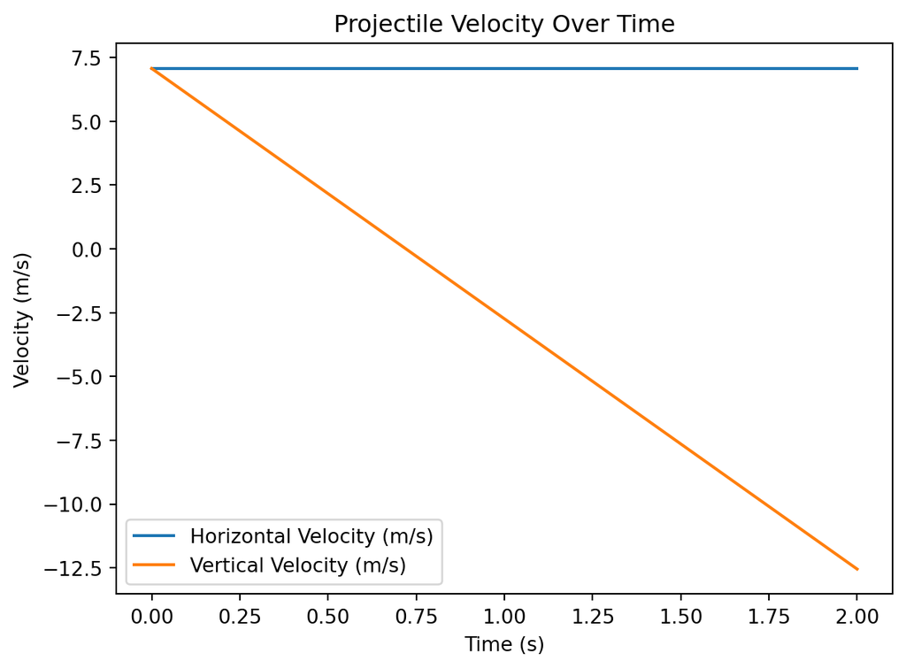

2. Write another function, `convert_to_polar(xv, yv)` that converts the horizontal and vertical velocity components into polar coordinates (magnitude and angle). The magnitude and angle can be calculated using the following equations:
   $$v_{mag} = \sqrt{v_x^2 + v_y^2}$$
   $$\theta = tan^{-1}(\frac{v_y}{v_x})$$

   An example usage of the function is shown below:

   tp, xv, yv = determine_velocity(10, np.pi/4, (0, 2, 0.2))

   v_mag, theta = convert_to_polar(xv, yv)

   v_mag

   array([10.0, 8.72367892, 7.73976975, 7.16968519, 7.1136224, 7.5829908, 8.49109907, 9.71569171, 11.15300207, 12.73118742, 14.40401677])

   theta

   array([0.78539816, 0.62568814, 0.4187404, 0.16605071, -0.10943583, -0.36954822, -0.58671765, -0.75568974, -0.88407412, -0.98193672, -1.057663])

**Callout-answer**Answer**

```
projectile_motion_with_velocity.py
```

```python
import numpy as np
def determine_velocity(v0: float, theta0: float, t_info: tuple[float, float, float]) \
    -> tuple[np.ndarray, np.ndarray, np.ndarray]:
    """
    Calculate the horizontal and vertical velocity components of a projectile over time.

    Parameters
    ----------
    v0 : float
        Initial velocity magnitude (m/s).
    theta0 : float
        Initial angle of projection (radians).
    t_info : tuple[float, float, float]
        Tuple containing start time, end time, and time step (s).

    Returns
    -------
    tp : ndarray[float]
        Time (s) at each step from t_start to t_end with step size dt.
    xv : ndarray[float]
        Horizontal velocity (m/s) at each corresponding time in tp.
    yv : ndarray[float]
        Vertical velocity (m/s) at each corresponding time in tp.
    """
    t_start, t_end, dt = t_info
    tp = np.arange(t_start, t_end + dt, dt)
    xv = v0 * np.cos(theta0) * np.ones_like(tp)
    yv = v0 * np.sin(theta0) - 9.81 * tp
    return tp, xv, yv

def convert_to_polar(xv: np.ndarray, yv: np.ndarray) -> tuple[np.ndarray, np.ndarray]:
    """
    Convert horizontal and vertical velocity components to polar coordinates (magnitude and angle).

    Parameters
    ----------
    xv : ndarray[float]
        Horizontal velocity components (m/s).
    yv : ndarray[float]
        Vertical velocity components (m/s).

    Returns
    -------
    v_mag : ndarray[float]
        Magnitude of velocity (m/s).
    theta : ndarray[float]
        Angle of velocity (radians).
    """
    v_mag = np.sqrt(xv**2 + yv**2)
    theta = np.arctan2(yv, xv)
    return v_mag, theta

# Example usage
tp, xv, yv = determine_velocity(10, np.pi/4, (0, 2, 0.2))
print(tp)
print(xv)
print(yv)
v_mag, theta = convert_to_polar(xv, yv)
print(v_mag)
print(theta)
```

Output

```
[0.  0.2 0.4 0.6 0.8 1.  1.2 1.4 1.6 1.8 2. ]
[7.07106781 7.07106781 7.07106781 7.07106781 7.07106781 7.07106781
 7.07106781 7.07106781 7.07106781 7.07106781 7.07106781]
[  7.07106781   5.10906781   3.14706781   1.18506781  -0.77693219
  -2.73893219  -4.70093219  -6.66293219  -8.62493219 -10.58693219
 -12.54893219]
[10.          8.72367892  7.73976975  7.16968519  7.1136224   7.5829908
  8.49109907  9.71569171 11.15300207 12.73118742 14.40401677]
[ 0.78539816  0.62568814  0.4187404   0.16605071 -0.10943583 -0.36954822
 -0.58671765 -0.75568974 -0.88407412 -0.98193672 -1.057663  ]
```